# R Notebook

Group 5, Matthew Hines, Emmanuel Garzo, Dustin Beaver

4/5/2020

# Guiding Question

What factors are common between all hall of fame MLB baseball players?

# Become Acquainted

- Data.World
- Authors of the data set are
  - Chris Dalzell
  - Michael Friendly
  - Dennis Murphys
  - Martin Monkman
  - Vanessa Foot & Justeena Zaki-Azat [vignettes]
- Collected orginally in 1996, there is no given reason for collection.
- There are 25 data sets included. the main focus will be on HallofFame, Pitching, Hitting, Fielding and Teams.
- The varaibles that will be mainly used are PLayerID, which is unique to each player and allow us to join tables and track player statistics

# Explore Intuition Related to the Research Question

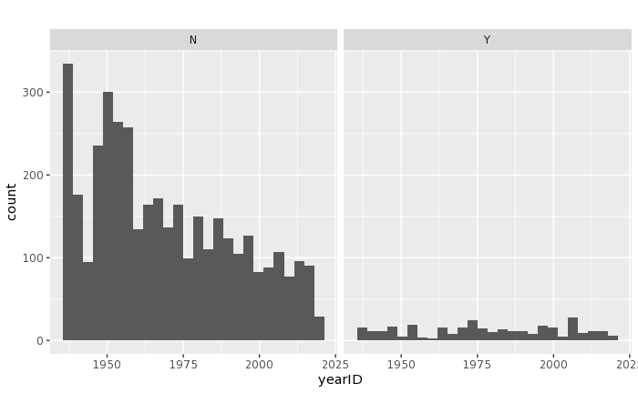

This plot shows the number of inducted players versus not inducted per year.

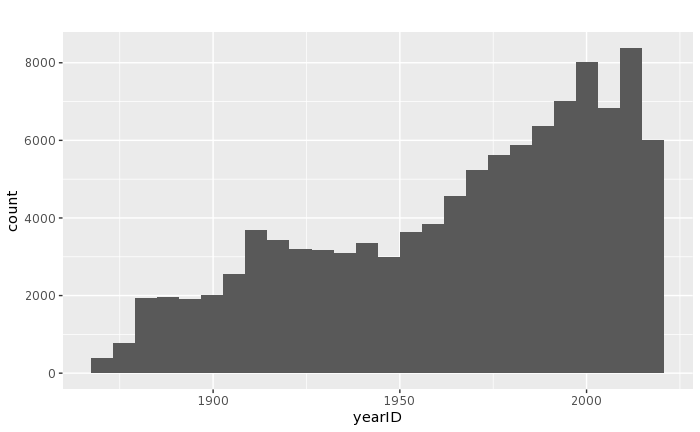

### Analyzing the Data

# TWO Data Sources

- Lahman’s Baseball DataBase, will be sourced by CSV files
- RetroSheet Game Log Data Set, it’s also a CSV